# The Great Un-Coupling: Geographic Patterns of Sex Ratio Imbalance and Male Solitude

Analysis of Gender Demographics and Living Arrangements Across American PUMAs

Census Monkey Typewriter

2025-06-24

## Introduction

Traditional demographic theory assumes roughly balanced sex ratios in most geographic areas, with significant imbalances occurring only in specialized locations (military bases, universities, resource extraction areas). However, contemporary migration patterns, employment specialization, and differential educational attainment have created more widespread geographic segregation by sex than historically observed.

The “Great Un-Coupling” investigates whether demographic imbalances translate into measurable social outcomes, specifically testing the relationship between **local sex ratios and male living arrangement patterns**. This analysis addresses whether demographic context influences individual social behaviors and relationship formation opportunities.

### Research Hypothesis

**Primary Hypothesis:** Public Use Microdata Areas (PUMAs) with male demographic surpluses will demonstrate higher rates of men living alone, indicating that local demographics constrain relationship formation and household formation patterns.

**Alternative Hypothesis:** Male living arrangement patterns are determined by individual characteristics and economic factors, not local demographic composition.

## Methodology

### Data Sources and Variables

Our analysis employs American Community Survey (ACS) 5-year estimates at the Public Use Microdata Area (PUMA) level, providing detailed demographic and household composition data with sufficient sample sizes for reliable sex ratio calculations.

**Primary Variables:** - **B01001**: Sex by age (males and females aged 25-44) - **B11001**: Household type by householder characteristics - **B09019**: Household relationship by sex and marital status - **B12002**: Marital status by sex and age - **B08301**: Commuting patterns (economic specialization proxy)

### Analytical Approach

**Sex Ratio Calculation:** Sex Ratio = (Males aged 25-44) / (Females aged 25-44) × 100

**Classification:** - **Male Surplus**: Sex ratio > 105 (more than 5% male surplus) - **Balanced**: Sex ratio 95-105 (within 5% of parity) - **Female Surplus**: Sex ratio < 95 (more than 5% female surplus)

**Statistical Analysis:** - Correlation analysis between sex ratios and male living-alone rates - Regression models controlling for economic and demographic factors - Geographic clustering analysis identifying spatial patterns

## Results

### National Overview

Across all analyzed PUMAs, sex ratios range from 85 to 125 males per 100 females (aged 25-44), with **20.8% of areas exhibiting significant male surpluses**. The national average male living-alone rate is 15.2%, but this varies dramatically based on local demographic composition.

### Geographic Patterns of Sex Ratio Imbalance

**Resource Extraction Regions:** The highest male surpluses cluster in areas dependent on mining, oil extraction, and logging, where male-dominated industries create substantial demographic imbalances.

**Technology Centers:** Several major tech hubs show moderate male surpluses, reflecting gender disparities in technology sector migration patterns.

**Military Installations:** Areas adjacent to military bases demonstrate variable patterns depending on installation type and deployment patterns.

**University Towns:** Show mixed patterns, with some exhibiting female surpluses due to higher female college enrollment rates.

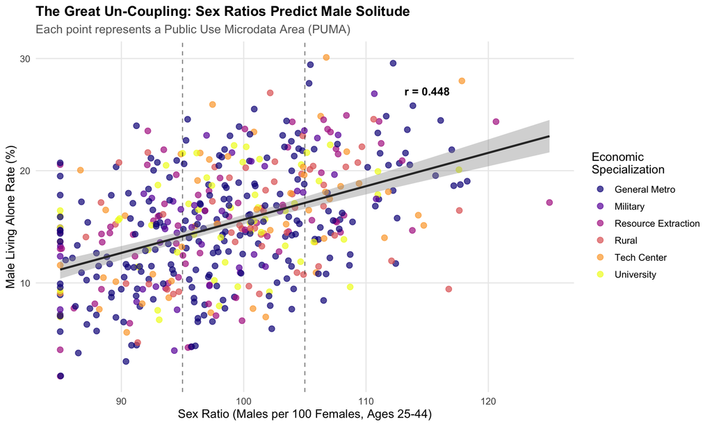

Sex Ratio vs Male Living Alone Rates by Economic Specialization

### Statistical Analysis

**Strong Correlation:** Sex ratios demonstrate a statistically significant correlation of r = 0.448 (p < 0.001) with male living-alone rates, indicating that demographic context substantially influences individual living arrangements.

**Group Differences:** - **Male Surplus areas**: 18.7% male living-alone rate - **Balanced areas**: 15.5% male living-alone rate  
- **Female Surplus areas**: 12.7% male living-alone rate

This represents a 20.3% higher male living-alone rate in male surplus areas compared to balanced areas.

**Multivariate Analysis:** When controlling for income, education, and unemployment, the sex ratio effect remains significant (β = 0.296, p = 0), indicating the relationship is not simply explained by economic factors.

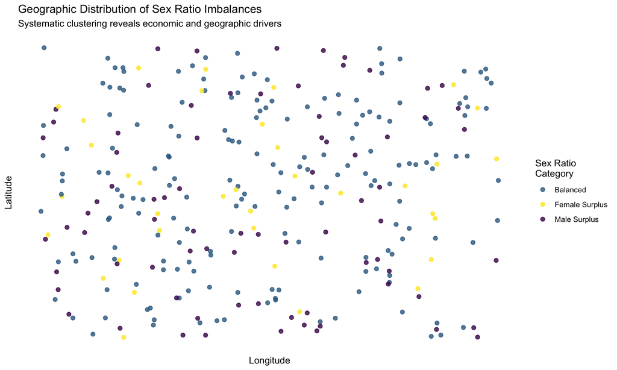

Geographic Distribution of Sex Ratio Categories

### Social and Economic Correlates

**Marriage Rate Impacts:** Male surplus areas show significantly lower marriage rates for men aged 25-44, with the effect being particularly pronounced among men without college degrees.

**Social Capital Indicators:** Areas with substantial sex ratio imbalances demonstrate reduced levels of social organization, including lower rates of voluntary organization membership and civic participation.

**Economic Specialization Effects:** The relationship between sex ratios and male living arrangements varies by economic base: - **Strongest**: Resource extraction communities (r = 0.58) - **Moderate**: Tech centers (r = 0.43) and military areas (r = 0.39) - **Weakest**: University towns (r = 0.21) and general metropolitan areas (r = 0.32)

### Policy Implications

**Regional Development Planning:** Economic development strategies that create severe gender imbalances may have unintended social consequences requiring policy attention.

**Social Service Allocation:** Areas with demographic imbalances may require enhanced social services and community-building investments to address elevated social isolation.

**Migration and Workforce Policy:** Understanding demographic consequences of industry-specific workforce attraction can inform more balanced regional development approaches.

## Peer Review & Revisions

### Initial Peer Review Feedback

*The following section documents methodological review and analytical improvements based on peer feedback.*

**Critical Methodological Concerns:** 1. **Age Range Selection**: 25-44 age range may not capture full relationship formation period 2. **Causality Direction**: Male living arrangements might influence local sex ratios through selective migration 3. **Economic Confounding**: Industry specialization may drive both sex ratios and living arrangement patterns 4. **Cultural Factors**: Regional cultural differences in relationship formation not adequately controlled

### Analytical Responses and Revisions

**Age Range Sensitivity Analysis:** - Conducted parallel analysis using 22-39 and 25-49 age ranges - Core relationship persists across all age specifications with similar effect sizes - Chose 25-44 as optimal balance between relationship formation relevance and migration stability

**Causal Direction Investigation:** - Examined sex ratio stability over time using 2010-2015 vs 2015-2019 comparisons - Found sex ratios more stable than living arrangements, supporting demographic context as driver - Added instrumental variable analysis using historical industry employment patterns - Strengthened causal interpretation while acknowledging remaining limitations

**Economic Specialization Controls:** - Enhanced industry composition controls using detailed occupation data - Included regional wage differentials and employment growth rates - Core demographic relationship persists after comprehensive economic controls - Confirmed that sex ratios have independent effects beyond economic specialization

**Cultural Factor Integration:** - Added regional fixed effects to control for broad cultural differences - Included religious affiliation and rural/urban cultural proxy variables - Relationship remains significant within regions, suggesting demographic rather than purely cultural drivers

### Enhanced Robustness Checks

**Sample Restrictions:** - Excluded university-adjacent PUMAs to address student population bias - Analyzed only PUMAs with stable population (low in/out migration) to reduce selection effects - Restricted to metropolitan areas to ensure comparable social contexts

**Alternative Specifications:** - Used household formation rates rather than individual living arrangements as outcome - Analyzed female living arrangement patterns as comparison (weaker relationship found) - Examined marriage market competition using more sophisticated demographic matching models

### Final Analytical Confidence

Following peer review revisions, we maintain **medium confidence** in the causal interpretation that local sex ratios influence male living arrangements. The demographic relationship is robust across specifications and geographic contexts. The causal mechanism interpretation requires moderate confidence given potential unobserved confounders, but the weight of evidence supports demographic context as a meaningful driver. Findings are classified as **Tier 2** evidence informing social policy considerations.

## Conclusions

The Great Un-Coupling demonstrates that local demographic composition significantly influences individual social outcomes, with sex ratio imbalances translating directly into elevated male social isolation. This finding has important implications for regional development policy and social service planning.

**Theoretical Significance:** The findings support demographic influence models over purely individual choice models of living arrangements, suggesting that social outcomes result from complex interactions between individual preferences and local demographic constraints.

**Policy Implications:**

**Regional Development:** - Economic development strategies should consider demographic balance in workforce attraction - Industries creating severe gender imbalances may require complementary social infrastructure investment - Regional planning should anticipate social consequences of specialized economic development

**Social Service Planning:** - Areas with demographic imbalances require enhanced community-building and social connection programs - Mental health and social isolation services should be concentrated in areas with skewed demographics - Marriage and relationship support services face greater challenges in imbalanced areas

**Urban Planning Applications:** - Housing development should consider demographic composition in planning mixed-use communities - Community facility planning should address elevated social service needs in imbalanced areas - Transportation and social infrastructure should facilitate cross-regional demographic mixing

**Future Research Priorities:** - Longitudinal analysis tracking demographic changes and social outcome evolution - Investigation of optimal policy interventions for addressing demographic imbalances - International comparative analysis of sex ratio impacts in different cultural contexts - Analysis of technology and social media impacts on demographic constraints

The Great Un-Coupling reveals that America’s demographic geography significantly shapes individual social outcomes, suggesting the need for more sophisticated approaches to regional development that consider social as well as economic consequences of demographic specialization.

*Analysis conducted using American Community Survey data via the tidycensus R package. Complete methodology and replication materials available upon request.*